# Analyzing campaign financing from 2018 Kansas State House Races

This is an analysis of campaign financing for State House races in Kansas from 2018 with the intention of identifying races with high potential for Democrats in 2020. This served as a proof-of-concept that expanded into [a larger article analyzing high potential State House races across the United States](https://www.data2thepeople.org/post/dems-donate-where-your-money-can-make-the-biggest-impact).

The original data for this particular analysis was provided by the Kansas Democratic Party but was noted as originally coming from [Follow The Money](https://www.followthemoney.org/).

To begin, I’ll initialize the R environment and load in the raw data.

```r
# remove any existing variables
rm(list = ls())

# load necessary packages
library(dplyr, quietly = T)
library(tidyr, quietly = T)
library(tidylog, quietly = T)
library(ggplot2, quietly = T)
library(scales, quietly = T)

# set folder path and move there
base_path <- "~/Desktop/Work/Applications/2020.10 - Reveal, Data Journalist/data-diary/"
setwd(base_path)

# import raw data (from FollowTheMoney)
dt.raw <- read.csv(paste0(base_path, "/data/KS_2018_FTM.csv"))
```

### Data summary and cleaning

Before proceeding with the actual analysis, I want to understand what is in data and see if there will be any necessary cleaning.

```r
# review summary of raw data
summary(dt.raw)
```

```
##  filing_jurisdiction                           candidate
##  KS:288              ALCALA, JOHN                   :  2
##  US: 29              HAULMARK, CHRIS                :  2
##                      ACREE, KRISTY                  :  1
##                      AMYX, MIKE                     :  1
##                      ANDERSON, ARDEN & COWSERT, DALE:  1
##                      ARNBERGER, TORY M              :  1
##                      (Other)                        :309
##          election_status         party     election_year   election_type
##  Lost-General    : 87    DEMOCRATIC :125   Min.   :2018   Special :  3
##  Lost-Primary    : 79    INDEPENDENT:  2   1st Qu.:2018   Standard:314
##  Withdrew-Primary:  3    LIBERTARIAN: 11   Median :2018
##  Won-General     :141    NONPARTISAN:  7   Mean   :2018
##  Won-Retention   :  7    REPUBLICAN :172   3rd Qu.:2018
##                                            Max.   :2018
##
##                         office_sought  incumbency_status    n_donors
##  GOVERNOR / LIEUTENANT GOVERNOR: 15   Challenger: 93     Min.   :    0.0
##  US HOUSE DISTRICT KS 003      : 12   Incumbent :128     1st Qu.:   31.0
##  US HOUSE DISTRICT KS 002      : 10   Open      : 96     Median :   77.0
##  SECRETARY OF STATE            :  7                      Mean   :  268.2
##  HOUSE DISTRICT 045            :  5                      3rd Qu.:  169.0
##  HOUSE DISTRICT 014            :  4                      Max.   :13648.0
##  (Other)                       :264
##  dollars_raised
##  Min.   :-3.699e+03
##  1st Qu.: 8.125e+03
##  Median : 2.077e+04
##  Mean   : 5.580e+07
##  3rd Qu.: 4.560e+04
##  Max.   : 1.764e+10
##
```

Based on the summary of the data alone, there are a few things that stand out:

1. There are two candidates that appear twice: John Alcala and Chris Haulmark. Based on the cell below, it appears John Alcala is actually a duplicate and should be removed. Meanwhile, Chris Haulmark actually ran in two different races (withdrew from the primary for U.S. House KS-3 seat and then ran for KS State HD-15), so that should stay as is.
2. One candidate (Jay Sidie) raised a negative amount of money. Based on review of [Follow The Money](https://www.followthemoney.org/show-me?dt=1&c-t-eid=40609519&c-t-id=227088) and [FEC filings](https://www.fec.gov/data/candidate/H6KS03241/), this does appear correct. He raised $49.5K but appears to have paid out a significant amount ($53.2K) to himself in “self-financing”.
3. One candidate (Jesse Moore) apparently raised $17B, which seems unlikely. Upon a re-review of [Follow The Money](https://www.followthemoney.org/show-me?dt=1&c-t-eid=45399247&c-t-id=261184), it should be $17,645.
4. One candidate(s) (Laura Kelly + Lynn Rogers) had 13.6K donors, more than 6K more than the next highest. Based on [FTM data](https://www.followthemoney.org/show-me?dt=1&s=KS&y=2018&c-r-ot=G&c-t-id=262264), this does seem correct and makes sense since they were running for statewide office of Governor/Lt. Governor.

```r
# look at data for two candidates that appear twice
dt.raw %>%
    filter(candidate %in% c("ALCALA, JOHN", "HAULMARK, CHRIS"))
```

```
## filter: removed 313 rows (99%), 4 rows remaining
```

| filing_jurisdiction | candidate | election_status | party | election_year | election_type | office_sought | incumbency_status | n_donors | dollars_raised |
| --- | --- | --- | --- | --- | --- | --- | --- | --- | --- |
| KS | ALCALA, JOHN | Won-General | DEMOCRATIC | 2018 | Standard | HOUSE DISTRICT 057 | Incumbent | 67 | 18675.00 |
| KS | ALCALA, JOHN | Won-General | DEMOCRATIC | 2018 | Standard | HOUSE DISTRICT 057 | Incumbent | 67 | 18675.00 |
| KS | HAULMARK, CHRIS | Lost-General | DEMOCRATIC | 2018 | Standard | HOUSE DISTRICT 015 | Open | 52 | 17442.68 |
| US | HAULMARK, CHRIS | Withdrew-Primary | DEMOCRATIC | 2018 | Standard | US HOUSE DISTRICT KS 003 | Open | 12 | 10982.00 |

```r
# look at all instances where candidate had negative amount raised
dt.raw %>%
    filter(dollars_raised < 0)
```

```
## filter: removed 316 rows (>99%), one row remaining
```

| filing_jurisdiction | candidate | election_status | party | election_year | election_type | office_sought | incumbency_status | n_donors | dollars_raised |
| --- | --- | --- | --- | --- | --- | --- | --- | --- | --- |
| US | SIDIE, JAY D | Lost-Primary | DEMOCRATIC | 2018 | Standard | US HOUSE DISTRICT KS 003 | Open | 92 | -3698.98 |

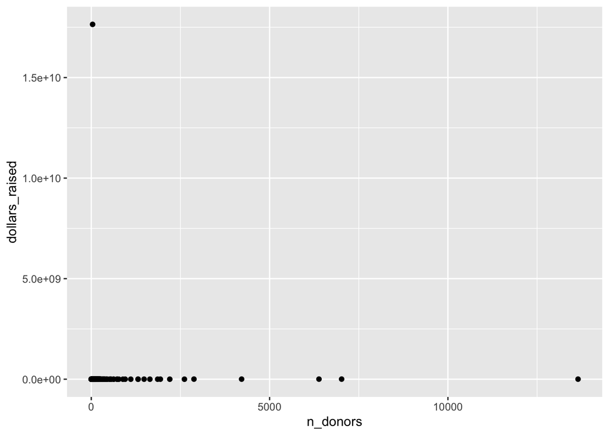

```r
# plot number of donors relative to dollars raised to show outlier of Jesse Moore (17B raised) and
ggplot(dt.raw, aes(x = n_donors, y = dollars_raised)) +
    geom_point()
```

```r
# look at top raising candidates to compare for outliers
dt.raw %>%
    arrange(-dollars_raised) %>%
    head(5)
```

|  | filing_jurisdiction | candidate | election_status | party | election_year | election_type | office_sought | incumbency_status | n_donors | dollars_raised |
| --- | --- | --- | --- | --- | --- | --- | --- | --- | --- | --- |
| 1 | KS | MOORE, JESSE C | Won-General | REPUBLICAN | 2018 | Standard | HOUSE DISTRICT 093 | Open | 37 | 17645000000 |
| 2 | US | DAVIDS, SHARICE | Won-General | DEMOCRATIC | 2018 | Standard | US HOUSE DISTRICT KS 003 | Challenger | 7019 | 4829498 |
| 3 | US | YODER, KEVIN W | Lost-General | REPUBLICAN | 2018 | Standard | US HOUSE DISTRICT KS 003 | Incumbent | 2879 | 4626050 |
| 4 | US | DAVIS, PAUL T | Lost-General | DEMOCRATIC | 2018 | Standard | US HOUSE DISTRICT KS 002 | Open | 6384 | 4368990 |
| 5 | KS | KOBACH, KRIS & HARTMAN, WINK | Lost-General | REPUBLICAN | 2018 | Standard | GOVERNOR / LIEUTENANT GOVERNOR | Open | 4215 | 4094580 |

```r
# look at candidates with the most donors to compare for outliers
dt.raw %>%
    arrange(-n_donors) %>%
    head(5)
```

|  | filing_jurisdiction | candidate | election_status | party | election_year | election_type | office_sought | incumbency_status | n_donors | dollars_raised |
| --- | --- | --- | --- | --- | --- | --- | --- | --- | --- | --- |
| 1 | KS | KELLY, LAURA J & ROGERS, LYNN | Won-General | DEMOCRATIC | 2018 | Standard | GOVERNOR / LIEUTENANT GOVERNOR | Open | 13648 | 3475428 |
| 2 | US | DAVIDS, SHARICE | Won-General | DEMOCRATIC | 2018 | Standard | US HOUSE DISTRICT KS 003 | Challenger | 7019 | 4829498 |
| 3 | US | DAVIS, PAUL T | Lost-General | DEMOCRATIC | 2018 | Standard | US HOUSE DISTRICT KS 002 | Open | 6384 | 4368990 |
| 4 | KS | KOBACH, KRIS & HARTMAN, WINK | Lost-General | REPUBLICAN | 2018 | Standard | GOVERNOR / LIEUTENANT GOVERNOR | Open | 4215 | 4094580 |
| 5 | US | YODER, KEVIN W | Lost-General | REPUBLICAN | 2018 | Standard | US HOUSE DISTRICT KS 003 | Incumbent | 2879 | 4626050 |

Based on this review, two necessary changes for manual cleaning:

1. Remove duplicate row for John Alcala
2. Correct the (possibly fat-finger) error in Jesse Moore’s fundraising to reflect $17,645 instead of $17B.

Beyond these updates, will also want to map each race to a race type to compare amount raised in aggregate.

```r
dt.clean <- dt.raw %>%

    # removed one duplicate (ALCALA, JOHN - HOUSE DISTRICT 057)
    distinct() %>%

    # fixed candidate's dollars_raised (see above)
    mutate(dollars_raised = ifelse(candidate == "MOORE, JESSE C" & office_sought == "HOUSE DISTRICT 093",
                                   17645, dollars_raised),

           # clean/recode to make office type groups
           office_type = recode(gsub("( )?[0-9]+", "", office_sought),
                                "APPELLATE COURT-POSITION" = "APPELLATE COURT",
                                "GOVERNOR / LIEUTENANT GOVERNOR" = "GUBERNATORIAL",
                                "BOARD OF EDUCATION DISTRICT" = "OTHER STATEWIDE",
                                "ATTORNEY GENERAL" = "OTHER STATEWIDE",
                                "INSURANCE COMMISSIONER" = "OTHER STATEWIDE",
                                "SECRETARY OF STATE" = "OTHER STATEWIDE",
                                "TREASURER" = "OTHER STATEWIDE",
                                "HOUSE DISTRICT" = "STATE HOUSE/ASSEMBLY",
                                "SENATE DISTRICT" = "STATE SENATE",
                                "US HOUSE DISTRICT KS" = "US HOUSE"))
```

```
## distinct: removed one row (<1%), 316 rows remaining
```

```
## mutate: changed one value (<1%) of 'dollars_raised' (0 new NA)
```

```
##         new variable 'office_type' (character) with 6 unique values and 0% NA
```

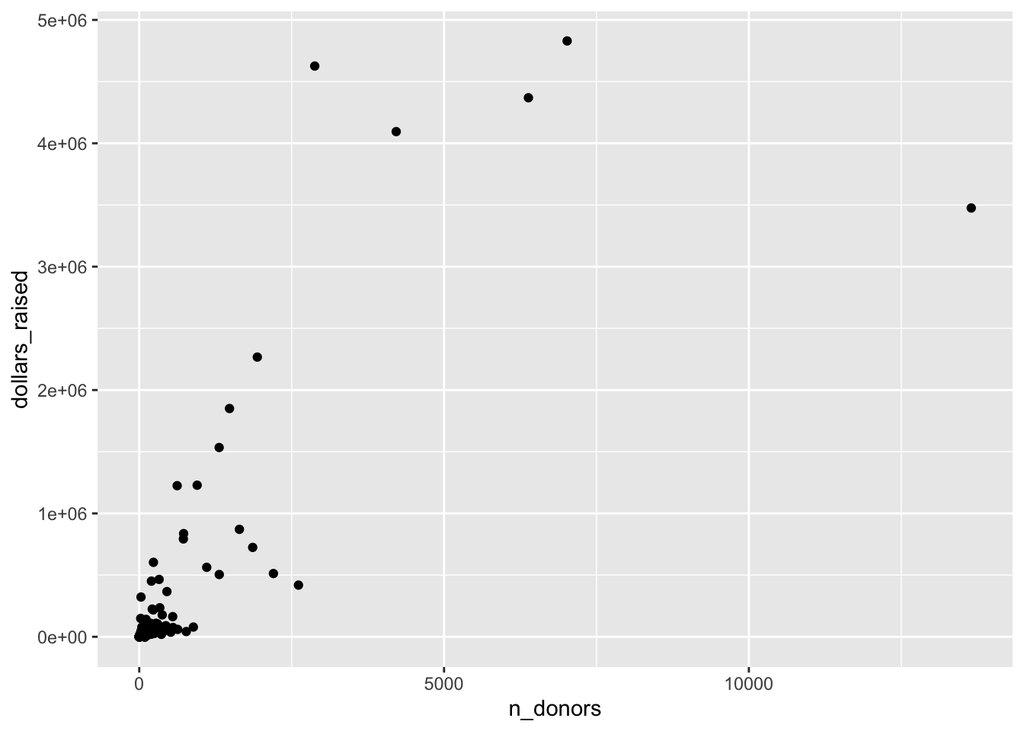

```r
# re-plot n_donors vs. dollars_raised with cleaned data; results seem more normal
ggplot(dt.clean, aes(x = n_donors, y = dollars_raised)) +
    geom_point()
```

With cleaner data, will want to perform a few minor sanity checks. First, we will want to check that there was one and only one winner for each of the 147 races we see in the data. We will also want to confirm that `Won-Retention` only applies to appellate court races.

```r
# aggregate by office type, office sought, and election status to find # of candidates falling into each category
# confirm that there are no instances where more than 1 winner AND that only appellate court races had retention winners
dt.clean %>%
    group_by(office_type, office_sought, election_status) %>%
    summarise(n = n()) %>%
    pivot_wider(id_cols = c("office_type", "office_sought"), names_from = election_status, values_from = n) %>%
    filter((`Won-Retention` > 0 & office_type != "APPELLATE COURT") |
               `Won-Retention` > 1 | `Won-General` > 1) %>%
    nrow()
```

```
## group_by: 3 grouping variables (office_type, office_sought, election_status)
```

```
## summarise: now 274 rows and 4 columns, 2 group variables remaining (office_type, office_sought)
```

```
## pivot_wider: reorganized (election_status, n) into (Won-Retention, Lost-General, Lost-Primary, Won-General, Withdrew-Primary) [was 274x4, now 147x7]
```

```
## filter (grouped): removed all rows (100%)
```

```
## [1] 0
```

Finally, we will just want to double check that our aggregate funraising amounts (`dollars_raised` and `n_donors`) lines up with the data shown on the [Follow The Money UI](https://www.followthemoney.org/show-me?dt=1&y=2018&s=KS&f-fc=1,2#%5B%7B1%7Cgro=c-r-ot,y).

```r
# aggregate n_donors and dollors_raised and compare to FTM data
dt.clean %>%
    group_by(office_type) %>%
    summarise(n_donors = sum(n_donors),
              dollars_raised = sum(dollars_raised)) %>%
    arrange(-dollars_raised)
```

```
## group_by: one grouping variable (office_type)
```

```
## summarise: now 6 rows and 3 columns, ungrouped
```

| office_type | n_donors | dollars_raised |
| --- | --- | --- |
| US HOUSE | 25901 | 21131683.5 |
| GUBERNATORIAL | 26800 | 14307891.8 |
| STATE HOUSE/ASSEMBLY | 26168 | 5822586.7 |
| OTHER STATEWIDE | 5690 | 3762219.4 |
| STATE SENATE | 385 | 156639.1 |
| APPELLATE COURT | 0 | 0.0 |

### Analyze the number of seats won by each party in 2018

For some basic understanding of the outcomes in 2018, we will first want to investigate the number of seats won each party across the different levels.

```r
dt.clean %>%
    filter(grepl("WON", toupper(election_status))) %>%
    group_by(party, office_type, filing_jurisdiction) %>%
    summarise(n = n()) %>%
    pivot_wider(id_cols = c("office_type", "filing_jurisdiction"), names_from = party, values_from = n)
```

```
## filter: removed 169 rows (53%), 147 rows remaining
```

```
## group_by: 3 grouping variables (party, office_type, filing_jurisdiction)
```

```
## summarise: now 9 rows and 4 columns, 2 group variables remaining (party, office_type)
```

```
## pivot_wider: reorganized (party, n) into (DEMOCRATIC, NONPARTISAN, REPUBLICAN) [was 9x4, now 6x5]
```

| office_type | filing_jurisdiction | DEMOCRATIC | NONPARTISAN | REPUBLICAN |
| --- | --- | --- | --- | --- |
| GUBERNATORIAL | KS | 1 | NA | NA |
| OTHER STATEWIDE | KS | 1 | NA | 8 |
| STATE HOUSE/ASSEMBLY | KS | 40 | NA | 85 |
| US HOUSE | US | 1 | NA | 3 |
| APPELLATE COURT | KS | NA | 7 | NA |
| STATE SENATE | KS | NA | NA | 1 |

### Analyze fundraising differentials in State House races

While it is not a given that the candidate who raises more wins, it has been found to be a huge predictor about electoral outcome. Depending on how we think about it, we can say (1) a high raising candidate indicates enthusiasm from voters who will turn out on Election Day, or (2) a high raising candidate has money to spend where money and ads lead to votes. It may be one or both of these, but there is no doubt that fundraising and fundraising differential between candidates can be a heavy indicator of performance.

Given that, let’s take a look at the 2018 races to see if there were any close races in terms of fundraising that might indicate potential for Dems (or Reps) in 2020.

For this, we will want to limit our data to fundraising amounts for State House candidates that made it to the General Election. For simplicity, I will also limit to just Democratic and Republican candidates, since there is no major 3rd party presence in Kansas ([ex. article](https://www.kcur.org/politics-elections-and-government/2018-06-05/centrist-third-party-falls-short-on-signatures-in-kansas)).

```r
money_raise_diff.by_race <- dt.clean %>%

    # limit to Ds + Rs running as general election candidates for state house elections
    # (don't want to include primary election candidate earnings + lib candidates)
    filter(office_type == "STATE HOUSE/ASSEMBLY" &
               grepl("General", election_status) &
               party %in% c("DEMOCRATIC", "REPUBLICAN")) %>%

    # determine which party won the seat (to be used in viz)
    mutate(winning_party = case_when(election_status == "Won-General" ~ substr(party, 1, 1),
                                     party == "REPUBLICAN" ~ "D",
                                     party == "DEMOCRATIC" ~ "R")) %>%

    # transpose data to have one row per race (keep track of $ and incumbency)
    pivot_wider(id_cols = c("office_sought", "winning_party"), names_from = party,
                values_from = c("dollars_raised", "incumbency_status")) %>%

    # calculate total amount raised in race and the differential (>0 = Rs)
    mutate(dollars_raised_total = replace_na(dollars_raised_REPUBLICAN, 0) + replace_na(dollars_raised_DEMOCRATIC, 0),
           more_dollars_raised_rep = replace_na(dollars_raised_REPUBLICAN, 0) - replace_na(dollars_raised_DEMOCRATIC, 0)) %>%
    arrange(more_dollars_raised_rep)
```

```
## filter: removed 130 rows (41%), 186 rows remaining
```

```
## mutate: new variable 'winning_party' (character) with 2 unique values and 0% NA
```

```
## pivot_wider: reorganized (filing_jurisdiction, candidate, election_status, party, election_year, …) into (dollars_raised_REPUBLICAN, dollars_raised_DEMOCRATIC, incumbency_status_REPUBLICAN, incumbency_status_DEMOCRATIC) [was 186x12, now 125x6]
```

```
## mutate: new variable 'dollars_raised_total' (double) with 125 unique values and 0% NA
```

```
##         new variable 'more_dollars_raised_rep' (double) with 125 unique values and 0% NA
```

```r
# look at races where candidate who raised more yet still lost
money_raise_diff.by_race %>%
    group_by(rep_raised_more = more_dollars_raised_rep > 0, winning_party) %>%
    summarise(n = n())
```

```
## group_by: 2 grouping variables (rep_raised_more, winning_party)
```

```
## summarise: now 4 rows and 3 columns, one group variable remaining (rep_raised_more)
```

| rep_raised_more | winning_party | n |
| --- | --- | --- |
| FALSE | D | 37 |
| FALSE | R | 9 |
| TRUE | D | 3 |
| TRUE | R | 76 |

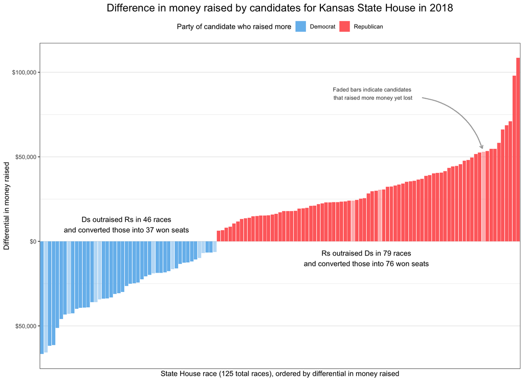

```r
# plot money raised differential by raise,
# color coding by party and using opacity to indicate if outraising party won
ggplot(money_raise_diff.by_race, aes(x = reorder(office_sought, more_dollars_raised_rep),
                                     y = more_dollars_raised_rep,
                                     fill = more_dollars_raised_rep > 0,
                                     alpha = case_when(more_dollars_raised_rep < 0 & winning_party == "D" ~ "Y",
                                                       more_dollars_raised_rep > 0 & winning_party == "R" ~ "Y",
                                                       T ~ "N"))) +
    geom_col() +
    annotate("text", x = 23, y = 1e4,
             label = "Ds outraised Rs in 46 races\nand converted those into 37 won seats") +
    annotate("text", x = 85.5, y = -1e4,
             label = "Rs outraised Ds in 79 races\nand converted those into 76 won seats") +
    geom_curve(x = 100, xend = 115.7, y = 8.5e4, yend = 5.5e4, curvature = -0.3, color = "#a9a9a9",
               arrow = arrow(length = unit(5, "points"))) +
    annotate("text", x = 87, y = 8.75e4, size = 3, alpha = 0.8,
             label = "Faded bars indicate candidates\n that raised more money yet lost") +
    scale_x_discrete(name = "State House race (125 total races), ordered by differential in money raised",
                     breaks = NULL) +
    scale_y_continuous(name = "Differential in money raised",
                       labels = function(x) dollar(abs(x))) +
    scale_fill_manual(name = "Party of candidate who raised more",
                      values = c("#77bdee", "#ff6e6c"),
                      labels = c("Democrat", "Republican")) +
    scale_alpha_manual(values = c("Y" = 1, "N" = 0.5)) +
    labs(title = "Difference in money raised by candidates for Kansas State House in 2018") +
    guides(alpha = FALSE) +
    theme_bw() +
    theme(plot.title = element_text(hjust = 0.5, size = 16),
          legend.position = "top")
```

We can see that, as expected, there is a very real correlation between amount raised and electoral performance. In 125 races, the candidate that raised more money won 90% of the time. Republican candidates often raised more than Democratic candidates and that paid off. They were also able to snatch slightlly more wins from Democratic candidates that raised more (Republicans won 9 seats where the Dem. candidate raised more; Dems did the opposite for only 3 seats).

### Identifying promising races for 2020

The results from 2018 do not spark a lot of encouragement for Dems in 2020, but it does show that there are a lot of areas where Dems *could* make gains. So how can we use 2018 fundraising to identify promising 2020 races? The biggest thing we will want to look for is small margins in fundraising differentials, which might indicate places where a better candidate or higher overall enthusiasm could lead to a win. So to identify small margins in fundrasing, we’ll first want to know what “small” means for these Kansas State House races.

```r
# analyze typical fundraising differential to identify what is a relatively small margin
money_raise_diff.by_race %>%
    pull(more_dollars_raised_rep) %>%
    abs() %>%
    quantile(c(0, 0.1, 0.2, 0.25, 0.5, 0.75, 1))
```

```
##        0%       10%       20%       25%       50%       75%      100%
##   6286.35  12148.47  15975.21  17942.59  26426.00  40238.77 108567.00
```

It seems that about 25% of our races were decided by around $18K, so for the purpose of identifying candidates, we can use this $18K as a benchmark.

Since we are just using 2018 fundraising data for this analysis (more discussion of this later), we are somewhat limited in what we can tell about the race. But, given what we have, it is worth looking for races that meet a few conditions:

1. **A Republican won the seat in 2018**: Dems will definitely want to focus on holding their ground in 2020, but if they want to make progress, the biggest priority should also be about flipping seats.
2. **The Republican that won in 2018 was not already an incumbent**: Incumbency gives a huge advantage, especially in smaller down ballot races, and running as a 2nd or 3rd term member gives even more of an advantage. With the data we have, we can’t tell if 2020 candidates will be incumbents, but for now, we will assume this is the case.
3. **The seat was contested in 2018**: There are a variety of locality-specific reasons that might make the race particularly difficult for Democrats (thus why no one ran in 2018) and without better local intuition, it can be hard to assess if this is the case from these data.

The last factor to consider is how large the fundraising differential was in comparison to the overall race. As a hypothetical, consider two races where the fundraising differential is $15,000 for both, but the overall amount raised in the second race is double that of the first. While investing $15,000 in both races would help close the gap, an additional $15,000 invested in the smaller campaign is worth significantly more in terms of marginal benefit. Thus, while all small differential races are important, we may want to initially focus on races where the differential is small and closing the small fundraising gap would also have the largest marginal benefit for the campaign as a whole.

Given all of that, let’s take a look at some (potentially) promising races.

```r
# look at races where a non-incumbent R won in a contest race
# further limit to races where the fundraising gap was <=18k (25th pctl)
# and calculate how large the gap was relative to the overall amount raised for the race
money_raise_diff.by_race %>%
    filter(winning_party == "R" & incumbency_status_REPUBLICAN != "Incumbent" & !is.na(dollars_raised_DEMOCRATIC)) %>%
    filter(between(more_dollars_raised_rep, 0, 18000)) %>%
    mutate(dollars_raised_diff_share = more_dollars_raised_rep / dollars_raised_total) %>%
    arrange(-dollars_raised_diff_share)
```

```
## filter: removed 109 rows (87%), 16 rows remaining
```

```
## filter: removed 13 rows (81%), 3 rows remaining
```

```
## mutate: new variable 'dollars_raised_diff_share' (double) with 3 unique values and 0% NA
```

| office_sought | winning_party | dollars_raised_REPUBLICAN | dollars_raised_DEMOCRATIC | incumbency_status_REPUBLICAN | incumbency_status_DEMOCRATIC | dollars_raised_total | more_dollars_raised_rep | dollars_raised_diff_share |
| --- | --- | --- | --- | --- | --- | --- | --- | --- |
| HOUSE DISTRICT 093 | R | 17645.00 | 2848.32 | Open | Open | 20493.32 | 14796.68 | 0.7220245 |
| HOUSE DISTRICT 005 | R | 21867.79 | 3951.92 | Open | Open | 25819.71 | 17915.87 | 0.6938835 |
| HOUSE DISTRICT 015 | R | 29149.00 | 17442.68 | Open | Open | 46591.68 | 11706.32 | 0.2512534 |

If we assume fundraising totals and gaps in 2018 are consistent with those from other years and thus reflect what we might expect for 2020, based on the logic laid out above, these three races appear as the most promising ones to look to in 2020. An additional $15K raised for any of these races would likely drastically grow a campaign’s war chest and could help overcome the fundraising gap, which we’ve seen to heavily correlate with winning elections.

### Expanding this analysis

As noted above, while fundraising data is a crucial part of analyzing elections, it is just one part of the larger picture, especially since we are only looking at one year. To further supplement and validate this analysis, it would be great to use and analyze (1) fundraising information from previous elections and (2) election results from previous elections.

First, historical fundraising information would help to validate the relationship between fundraising gap and election outcome if we look across races. We could also use this historical information to better understand the fundraising gaps we see for 2018 (e.g., to assess if Democrats historically have a difficult time raising money in a particular district or if the 2018 candidate was not a particularly strong candidate or fundraiser).

Second, historical election results may also help identify where marginal increases in funding could lead to meaningful election outcomes. If we were to see that, hypothetically, $10,000 of additional funding correlates with a two-point improvement in election results, it would be better to invest $10,000 in a district with a one- or two-point difference rather than one separated by ten points. Therefore, having insight into historical trends in election performance can help calibrate where or how we choose to invest resources.

Both of these datasets would help us understand the historical context behind certain races. While we saw a significant relationship between the existence of a fundraising gap and the ultimate election outcome in 2018, it would be worthwhile to expand this analysis to verify the correlation. Additionally, while we suspect there is a correlation, there are many other factors that influence this relationship, and if we can identify races that seem to buck this trend, it may better inform us if we should indeed invest resources into these campaigns.